# Practical Machine Learning

Ruben_Mkrtchyan

18/05/2021

# Practical Machine Learning

# Ruben Mkrtchyan

## I.Overview

This report is the final assignment for Coursera’s Practical Machine Learning course. This course is a part of the Data Science Specialization track which is organized by John Hopkins University. This report will be graded by peers of the same course.

The report will use data from accelerometers on forearm, arm, belt and dumbel of six participants. The data consists of a training data and a test data, which is for validating the selected model.The goal of the report is to predict the way that the participants performed the excercise. That is the “classe” variable in the training set. There will be three models trained in this report, those are:Decision Tree, Random Forest and Gradient Boosted Trees. The best model will be sellected based on the accuracy rate and out of sample error rate. By the use of the selected model, the twenty test cases available in the test data will be predicted.

## II.Backgroung

Using devices such as Jawbone Up, Nike FuelBand, and Fitbit it is now possible to collect a large amount of data about personal activity relatively inexpensively. These type of devices are part of the quantified self movement – a group of enthusiasts who take measurements about themselves regularly to improve their health, to find patterns in their behavior, or because they are tech geeks. One thing that people regularly do is quantify how much of a particular activity they do, but they rarely quantify how well they do it. In this project, your goal will be to use data from accelerometers on the belt, forearm, arm, and dumbell of 6 participants. They were asked to perform barbell lifts correctly and incorrectly in 5 different ways. More information is available from the website here: http://groupware.les.inf.puc-rio.br/har (see the section on the Weight Lifting Exercise Dataset).

The training data for this project are available here: https://d396qusza40orc.cloudfront.net/predmachlearn/pml-training.csv

The test data are available here: https://d396qusza40orc.cloudfront.net/predmachlearn/pml-testing.csv

## III.Data Loading, preprocessing and cleaning

### a)Data Preprocessing and package instalation:

At first, we need to upload the necessary libraries.

```r
#install.packages('caret', dependencies = TRUE)
#install.packages('gtable', dependencies = TRUE)
#install.packages('ggplot2', dependencies = TRUE)
#install.packages('gower', dependencies = TRUE)
```

```r
#install.packages('jquerylib', dependencies = TRUE)
```

```r
library(caret)
```

```r
library(lattice)
library(ggplot2)
library(corrplot)
library(knitr)
library(rpart)
library(rpart.plot)
library(rattle)
library(randomForest)
set.seed(404) #Setting the seed
```

### b)Data Reading:

Now we read the data.

```r
Url_train <- "http://d396qusza40orc.cloudfront.net/predmachlearn/pml-training.csv"
Url_test  <- "http://d396qusza40orc.cloudfront.net/predmachlearn/pml-testing.csv"

train_data <- read.csv(url(Url_train))
test_data  <- read.csv(url(Url_test))

inTrain  <- createDataPartition(train_data$classe, p=0.7, list=FALSE)
Train_Set <- train_data[inTrain, ]
Test_Set  <- train_data[-inTrain, ]
```

Let’s check the number of variables of Train_Set and Test_Set.

```r
dim(Train_Set)
```

```
## [1] 13737   160
```

```r
dim(Test_Set)
```

```
## [1] 5885  160
```

As we see, we have got 160 initial variables, however after data cleaning the number will be reduced.

### c)Data Cleaning:

We need to remove the near zero variance (NZV) variables.

```r
NZV <- nearZeroVar(Train_Set)
Train_Set <- Train_Set[, -NZV]
Test_Set  <- Test_Set[, -NZV]
```

```r
dim(Train_Set)
```

```
## [1] 13737   105
```

```r
dim(Test_Set)
```

```
## [1] 5885  105
```

As we see, the number of variables are reduced to 105 for both Test_Set and Train_Set.

Now, we need to clean the variables with mostly NA values.

```r
NA_val    <- sapply(Train_Set, function(x) mean(is.na(x))) > 0.8
Train_Set <- Train_Set[, NA_val==FALSE]
Test_Set  <- Test_Set[, NA_val==FALSE]
```

```r
dim(Train_Set)
```

```
## [1] 13737    59
```

```r
dim(Test_Set)
```

```
## [1] 5885   59
```

Let’s check the remaining variables in the reduced sets.

```r
head(Test_Set)
```

```
##     X user_name raw_timestamp_part_1 raw_timestamp_part_2   cvtd_timestamp
## 5   5  carlitos           1323084232               196328 05/12/2011 11:23
## 7   7  carlitos           1323084232               368296 05/12/2011 11:23
## 8   8  carlitos           1323084232               440390 05/12/2011 11:23
## 13 13  carlitos           1323084232               560359 05/12/2011 11:23
## 14 14  carlitos           1323084232               576390 05/12/2011 11:23
## 22 22  carlitos           1323084232               892313 05/12/2011 11:23
##    num_window roll_belt pitch_belt yaw_belt total_accel_belt gyros_belt_x
## 5          12      1.48       8.07    -94.4                3         0.02
## 7          12      1.42       8.09    -94.4                3         0.02
## 8          12      1.42       8.13    -94.4                3         0.02
## 13         12      1.42       8.20    -94.4                3         0.02
## 14         12      1.42       8.21    -94.4                3         0.02
## 22         12      1.57       8.09    -94.4                3         0.02
##    gyros_belt_y gyros_belt_z accel_belt_x accel_belt_y accel_belt_z
```

[output cut: 69 more lines]

As we see, the first five variables are just identification variables, so we need to clean those too.

```r
Train_Set <- Train_Set[, -(1:5)]
Test_Set  <- Test_Set[, -(1:5)]
```

```r
dim(Train_Set)
```

```
## [1] 13737    54
```

```r
dim(Test_Set)
```

```
## [1] 5885   54
```

So, after removing mostly NA variables, NZV variables and the first five identification variables we are left to 54 final variables.

### d)Correlation Analysis

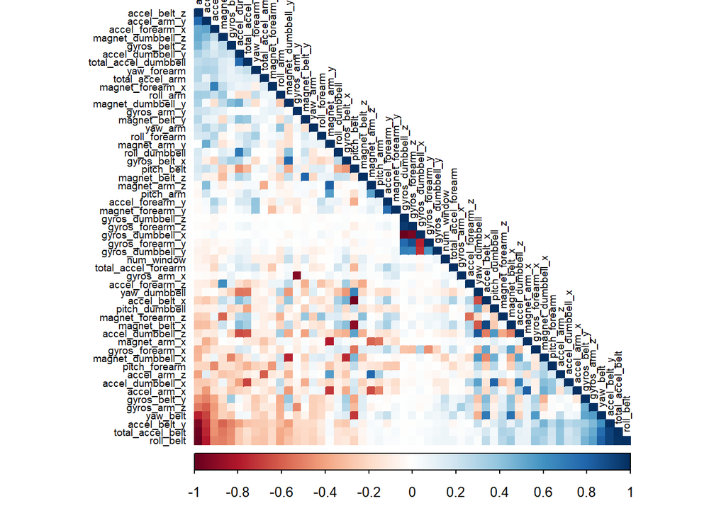

```r
corelation_matrix <- cor(Train_Set[, -54])
corrplot(corelation_matrix, order = "FPC", method = "color", type = "lower",
         tl.cex = 0.6, tl.col = rgb(0, 0, 0))
```

Here, in the correlation matrix, the red and blue colors are associated with -1 and 1 correlation respectively. The bright colors show small amount of correlations between the remaining 54 variables.

## IV.Buliding and Testing the Models

### a)Model 1:Decision Tree

#### i) The Model

The first model that we will use is Decision Trees. At first we need to get the model, then we use fancyRpartPlot() function to plot the classification tree.

[figure not shown]

```r
control_var <- trainControl(method="cv", number=3, verboseIter=F)
DT_Model <- train(classe~., data=Test_Set, method="rpart", trControl = control_var, tuneLength = 3)
fancyRpartPlot(DT_Model$finalModel)
```

#### ii) The prediction

Now that we already have the model, we need to validate it on Train_Set.

```r
TS_Factored <- factor(Train_Set$classe)
DT_Prediction <- predict(DT_Model, Train_Set)
cmtree <- confusionMatrix(DT_Prediction, TS_Factored)
cmtree
```

```
## Confusion Matrix and Statistics
##
##           Reference
## Prediction    A    B    C    D    E
##          A 3571 1162 1164 1028  358
##          B   47  636   35  383  137
##          C  280  860 1197  841  878
##          D    0    0    0    0    0
##          E    8    0    0    0 1152
##
## Overall Statistics
##
##                Accuracy : 0.4773
##                  95% CI : (0.4689, 0.4856)
##     No Information Rate : 0.2843
##     P-Value [Acc > NIR] : < 2.2e-16
##
##                   Kappa : 0.3165
##
##  Mcnemar's Test P-Value : NA
##
## Statistics by Class:
##
##                      Class: A Class: B Class: C Class: D Class: E
## Sensitivity            0.9142  0.23928  0.49958   0.0000  0.45624
## Specificity            0.6224  0.94566  0.74791   1.0000  0.99929
## Pos Pred Value         0.4903  0.51373  0.29512      NaN  0.99310
## Neg Pred Value         0.9481  0.83823  0.87615   0.8361  0.89083
## Prevalence             0.2843  0.19349  0.17442   0.1639  0.18381
## Detection Rate         0.2600  0.04630  0.08714   0.0000  0.08386
## Detection Prevalence   0.5302  0.09012  0.29526   0.0000  0.08444
## Balanced Accuracy      0.7683  0.59247  0.62374   0.5000  0.72776
```

As we see, the accuracy rate is 0.4773 and the out of sample error rate is 1-accuracy = 0.5227

### b)Model 2:Random Forest

#### i) The Model

Our second model is Random Forest.

```r
control_RF <- trainControl(method="cv", number=3, verboseIter=FALSE)
RF_Model <- train(classe ~ ., data=Train_Set, method="rf", trControl=control_RF)
RF_Model$finalModel
```

```
##
## Call:
##  randomForest(x = x, y = y, mtry = param$mtry)
##                Type of random forest: classification
##                      Number of trees: 500
## No. of variables tried at each split: 27
##
##         OOB estimate of  error rate: 0.26%
## Confusion matrix:
##      A    B    C    D    E  class.error
## A 3904    1    0    0    1 0.0005120328
## B   10 2644    4    0    0 0.0052671181
## C    0    5 2391    0    0 0.0020868114
## D    0    0    7 2244    1 0.0035523979
## E    0    1    0    6 2518 0.0027722772
```

#### ii) The prediction

```r
#RF <- train(classe~., data=Train_Set, method="rf", trControl = control_var)
RF_Prediction <- predict(RF_Model, Train_Set)
cmrf <- confusionMatrix(RF_Prediction, TS_Factored)
cmrf
```

```
## Confusion Matrix and Statistics
##
##           Reference
## Prediction    A    B    C    D    E
##          A 3906    0    0    0    0
##          B    0 2658    0    0    0
##          C    0    0 2396    0    0
##          D    0    0    0 2252    0
##          E    0    0    0    0 2525
##
## Overall Statistics
##
##                Accuracy : 1
##                  95% CI : (0.9997, 1)
##     No Information Rate : 0.2843
##     P-Value [Acc > NIR] : < 2.2e-16
##
##                   Kappa : 1
##
##  Mcnemar's Test P-Value : NA
##
## Statistics by Class:
##
##                      Class: A Class: B Class: C Class: D Class: E
## Sensitivity            1.0000   1.0000   1.0000   1.0000   1.0000
## Specificity            1.0000   1.0000   1.0000   1.0000   1.0000
## Pos Pred Value         1.0000   1.0000   1.0000   1.0000   1.0000
## Neg Pred Value         1.0000   1.0000   1.0000   1.0000   1.0000
## Prevalence             0.2843   0.1935   0.1744   0.1639   0.1838
## Detection Rate         0.2843   0.1935   0.1744   0.1639   0.1838
## Detection Prevalence   0.2843   0.1935   0.1744   0.1639   0.1838
## Balanced Accuracy      1.0000   1.0000   1.0000   1.0000   1.0000
```

### b)Model 3:Generalized Boosted Model (GBM)

#### i) The Model

```r
control_GBM <- trainControl(method = "repeatedcv", number = 5, repeats = 1)
GBM_Model  <- train(classe ~ ., data=Train_Set, method = "gbm", trControl = control_GBM)
GBM_Model$finalModel
```

```
## A gradient boosted model with multinomial loss function.
## 150 iterations were performed.
## There were 53 predictors of which 53 had non-zero influence.
```

#### ii) The prediction

```r
GBM_Prediction <- predict(GBM_Model, newdata=Test_Set)
```

```r
GBM_Conf_Matrix <- confusionMatrix(factor(GBM_Prediction), factor(Test_Set$classe))
GBM_Conf_Matrix
```

```
## Confusion Matrix and Statistics
##
##           Reference
## Prediction    A    B    C    D    E
##          A 1672   10    0    0    0
##          B    1 1119    9    4    1
##          C    0   10 1014    8    0
##          D    1    0    3  950    6
##          E    0    0    0    2 1075
##
## Overall Statistics
##
##                Accuracy : 0.9907
##                  95% CI : (0.9879, 0.993)
##     No Information Rate : 0.2845
##     P-Value [Acc > NIR] : < 2.2e-16
##
##                   Kappa : 0.9882
##
##  Mcnemar's Test P-Value : NA
##
## Statistics by Class:
##
##                      Class: A Class: B Class: C Class: D Class: E
## Sensitivity            0.9988   0.9824   0.9883   0.9855   0.9935
## Specificity            0.9976   0.9968   0.9963   0.9980   0.9996
## Pos Pred Value         0.9941   0.9868   0.9826   0.9896   0.9981
## Neg Pred Value         0.9995   0.9958   0.9975   0.9972   0.9985
## Prevalence             0.2845   0.1935   0.1743   0.1638   0.1839
## Detection Rate         0.2841   0.1901   0.1723   0.1614   0.1827
## Detection Prevalence   0.2858   0.1927   0.1754   0.1631   0.1830
## Balanced Accuracy      0.9982   0.9896   0.9923   0.9917   0.9966
```

### V. Best Model Selection and its Validation on test_data

```r
Predict_Results <- predict(RF_Model, test_data)
Predict_Results
```

```
##  [1] B A B A A E D B A A B C B A E E A B B B
## Levels: A B C D E
```